# Communicate Data Findings : Loan Data from Prosper by Ilknur Cakir

### Borrower Rate and Credit Risk Score

We have seen in the previous section that there is a correlation between term and rate. As term increases, borrower rate generally increases. So the relationship between borrower rate and credit risk score is plotted for different term values, 12 month, 36 month and 60 month. The negative relationship between rate and score is apparent especially for 60 month loans in the plot. But it is not very obvious for 12 and 36 month loans. So I want to look at the distribution of interest rate for different risk score values. For that, I use violin plot, it is given below.

As score increases average rate values decrease. The last regression plots show that this relationship does not change for different term values.

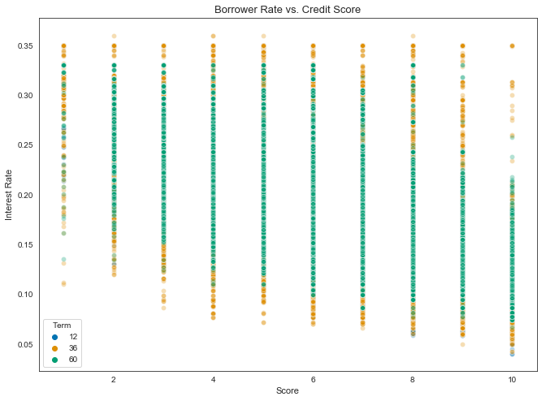

```python
# Scatter plot of interest rate and risk score for different term values.
# First I define plot_data to include only 12, 36 or 60 month loans. Then I plot
# them with different colors.Legend shows which color is for which term.

plt.figure(figsize = (11,8))
colors = sns.color_palette('colorblind', 3)
for i, color in zip([12, 36, 60], colors):
    plot_data = dff[dff.Term == i]
    sns.scatterplot(data = plot_data, y = 'BorrowerRate', x = 'ProsperScore', color = color,
                   alpha = 0.1)

# legend object
legend_obj = []
for color in colors:
    legend_obj.append(plt.scatter([], [], color = color))

plt.legend(legend_obj, ['12', '36', '60'], title = 'Term');
plt.title('Borrower Rate vs. Credit Score', fontsize = 13);
plt.xlabel('Score', fontsize = 11)
plt.ylabel('Interest Rate', fontsize = 11 );
```

It is seen in the violin plot that as score increases, the mean interest rate decreases. Also, for small and large score values the distributions are more compact whereas for middle score values they are more spread. The relationship is even more clear in the pointplot given below. Except at one point, the average interest rate always decreases as score increases. So people with a good credit score get a loan cheaper. In these violin and point plots, we did not take the term into account. It is important to make a dsitinction between different term values since term is another factor affecting interest rates.

The last plot in this subsection gives the regression plot of risk score and interest rate for different values. In all of them, the regression line has a negative slope. So we are sure to say that there is a negative correlation between score and borrower rate.

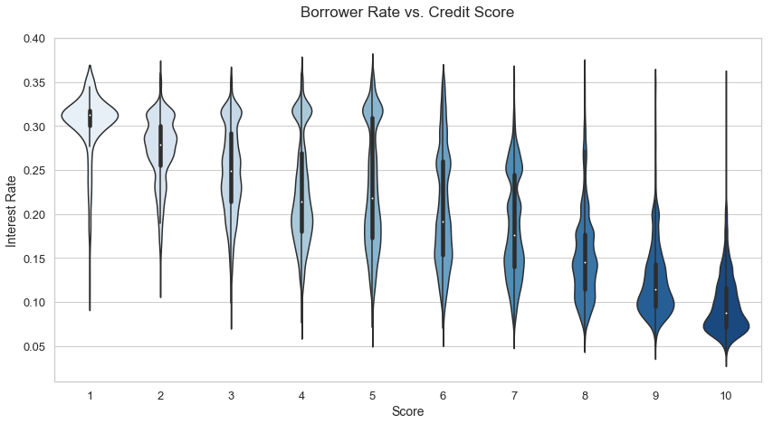

```python
# Violin plot for risk score and interest rate.
plt.figure(figsize= (14, 7))
sns.violinplot(data = dff, x = 'ProsperScore',  y = 'BorrowerRate', palette = 'Blues');
plt.title('Borrower Rate vs. Credit Score\n', fontsize = 17);
plt.xlabel('Score', fontsize = 14)
plt.ylabel('Interest Rate', fontsize = 14 );

# Polishing graph. Represent risk scores as an integer instead of float, 10 instead of 10.0 on the graph
ticks = np.arange(0, 9+1, 1)
labels = ['%d' % (i+1) for i in ticks]
plt.xticks(ticks, labels, fontsize = 13);
plt.yticks(fontsize = 13);
```

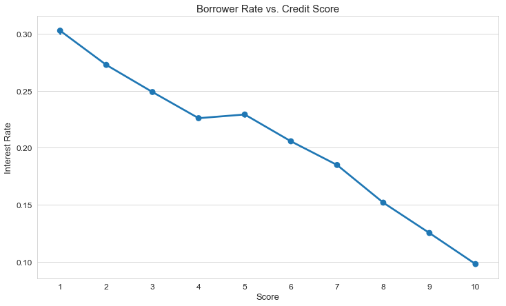

```python
# Point plot for risk score and interest rate. Average interest rate with increasing risk scores.

plt.figure(figsize = (12, 7))
sns.pointplot(data = dff, x = 'ProsperScore', y = 'BorrowerRate');
plt.title('Borrower Rate vs. Credit Score', fontsize = 15);
plt.xlabel('Score', fontsize = 13)
plt.ylabel('Interest Rate', fontsize = 13);

# Polishing graph. Represent risk scores as an integer instead of float, 10 instead of 10.0 on the graph
ticks = [i for i in np.arange(0,10)]
labels = [i+1 for i in ticks]
plt.xticks(ticks, labels, fontsize = 12);
plt.yticks(fontsize = 12);
```

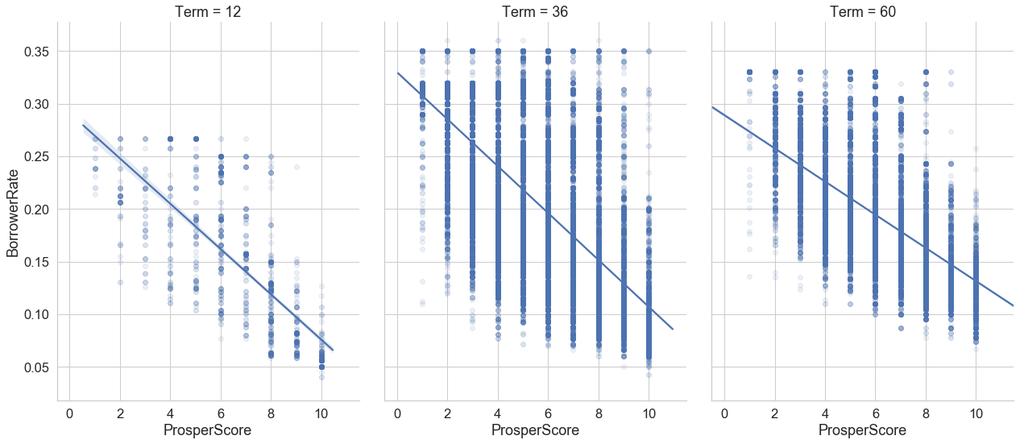

```python
# Regresion plots by fecetgrid for term values 12, 36 and 60.

sns.set(font_scale = 1.5)
sns.set_style('whitegrid')
g = sns.FacetGrid(data = dff, col = 'Term', col_order = [12, 36, 60], col_wrap = 3, height = 8, aspect = 0.75)
g = g.map(sns.regplot, 'ProsperScore', 'BorrowerRate', scatter_kws = {'alpha':0.1})
```

```python
dff = pd.read_csv('clean_data.csv')
```

### Borrower Rate and Term

Intuitively, we can expect to see a positive correlation between term and interest rate since there is a time value of money. The same amount of money next year worths smaller than the same amount of money this year. If we wait longer to get the money paid back, we want to charge more. In the point plot below, 60-month loans do have a smaller average intrest rate than the 36-month loans. It seems counterintuitive. We might expect to see finer details if we hold credit risk score constant as we know from the previous sebsection that there is a negative correlation between borrower rate and risk score. So I next look at the distributions of borrower rates for different terms are given for 2 different score levels, 4 and 8.

When the score is 4, average rate increases first and decreases from 36-month loans to 60-month loans. For score of 8, average term increases as term increases. So we can say that roughly as term increases borrower rate increases too.

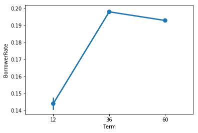

```python
# Pointplot of borrower's rate and term
sns.pointplot(data = dff, y = 'BorrowerRate', x = 'Term');
```

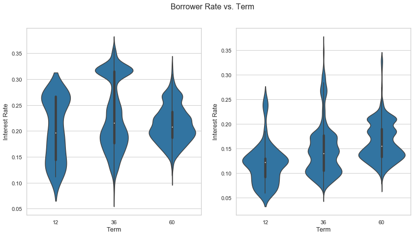

```python
# Borrower Rate vs. Term for different risk scores, 4 and 8.
# First get all samples with risk score 4 and 8 call them plot_data.
# Then plot violinplot of interest rate for different term values.

sns.set(font_scale = 1)
sns.set_style('whitegrid')
fig, axes = plt.subplots(1, 2, figsize = (14,7))
plot_data4 = dff[dff.ProsperScore == 4]
sns.violinplot(data = plot_data4, x = 'Term', y = 'BorrowerRate', ax = axes[0], color = base_color);
axes[0].set_xlabel('Term', fontsize = 13)
axes[0].set_ylabel('Interest Rate', fontsize = 13)

plot_data8 = dff[dff.ProsperScore == 8]
sns.violinplot(data = plot_data8, x = 'Term', y = 'BorrowerRate', ax = axes[1], color = base_color);
axes[1].set_xlabel('Term', fontsize = 13)
axes[1].set_ylabel('Interest Rate', fontsize = 13)
plt.suptitle('Borrower Rate vs. Term', fontsize = 16);
```

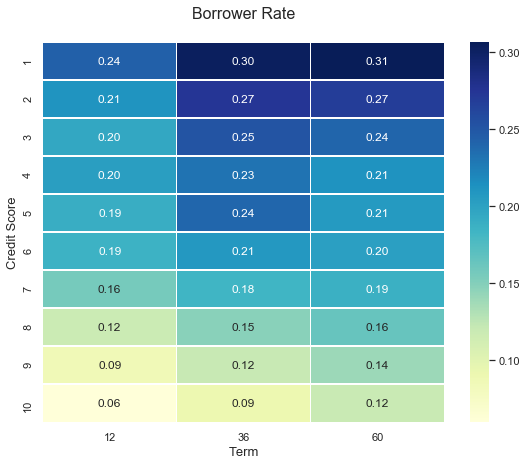

```python
# Heatmap showing the mean interest rate values for different credit risk score and term values.
# First create crosstab and then plot it.

plt.figure(figsize = (9, 7))
sns.set(font_scale = 1)
crosstab = pd.crosstab(dff['ProsperScore'], dff['Term'], values = dff['BorrowerRate'], aggfunc = 'mean');
sns.heatmap(crosstab, annot = True, fmt = '.2f', cmap= 'YlGnBu', linewidths= .5);

# Polishing the plot. Showing scores as an integer instead of float on the y axis, 10 instead of 10.0 and
# setting title and labels

ticks = np.arange(0.5, 9.5+1, 1)
labels = ['%d' % (i+1) for i in ticks]
plt.yticks(ticks, labels, fontsize = 11);
plt.title('Borrower Rate\n', fontsize = 16);
plt.xlabel('Term', fontsize = 13)
plt.ylabel('Credit Score', fontsize = 13);
```

### Borrower Rate and Original Loan Amount

First I try to see the relationship between loan amount and interest rate from scatter plot. Even though, there seems to be a negative correlation, the plot is not very clear since there are a lot of points in the dataset. So I try 2 dimensional histogram. It is given below.

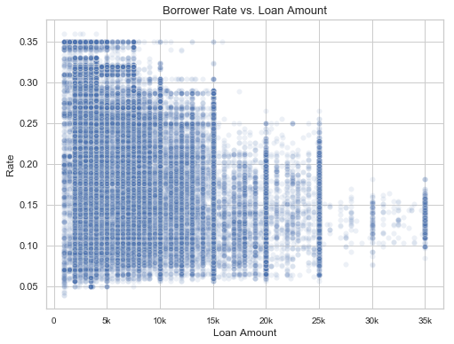

```python
# Scatter plot of LoanOriginalAmount and BorrowerRate.

sns.set_style('whitegrid')
plt.figure(figsize = (8,6))
sns.scatterplot(data = dff, x = 'LoanOriginalAmount', y = 'BorrowerRate', alpha = 0.1);

# Setting title, labels and ticks on the x-axis.

plt.xlabel('Loan Amount')
plt.ylabel('Rate')
plt.title('Borrower Rate vs. Loan Amount', fontsize = 13);

# Polishing here. 5k instead of 5000 on the x-axis.

ticks = np.arange(0, 35000 + 5000, 5000)
labels = ['0', '5k', '10k', '15k', '20k', '25k', '30k', '35k']
plt.xticks(ticks, labels, fontsize = 10);
```

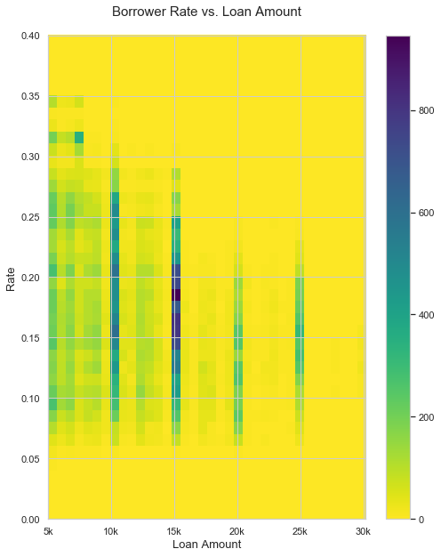

```python
# 2 dimensional histogram of LoanOriginalAmount and BorrowerRate.

plt.figure(figsize = (8, 10))
x_bins = np.arange(5000, 30000+500, 700)
y_bins = np.arange(0, 0.4+0.01, 0.01)
plt.hist2d(data = dff, x = 'LoanOriginalAmount', y = 'BorrowerRate', bins = [x_bins, y_bins], cmap= 'viridis_r');
plt.colorbar();

# Setting title, labels and ticks on the x-axis.
plt.xlabel('Loan Amount', fontsize = 13)
plt.ylabel('Rate', fontsize = 13)
plt.title('Borrower Rate vs. Loan Amount\n', fontsize = 15);

# Polishing here. 5k instead of 5000 on the x-axis.
ticks = np.arange(5000, 30000 + 5000, 5000)
labels = ['5k', '10k', '15k', '20k', '25k', '30k']
plt.xticks(ticks, labels, fontsize = 11);
```

There is a negative correlation between loan amount and borrower rate. As loan amount increases, the range of borrower rates get smaller, upper end of that range moves downward and lower end of the range stays the same. It basically says that the largest interest rates charged for large loans are smaller than the largest interest rates for smaller loans. It might happen because large loans are only given to customers with good score and are not given to customers with bad score. That's why we see lower rates for larger loans. We will dig into that when we look at the dfferences between loans wih small and large amounts.

To be able to better see the relationship, I point plot interest rate and loan amount. First I bin loan amount, from 1 to 12 where 1 is for the smallest loans and 12 for the largest ones. Plot gives the average interest rate for increasing loan amount bins. There is a negative relationship but it is not monotonic. When the loan amount bin increase from 7 to 9 and from 10 to 12, the average interest rate increases.

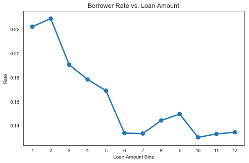

```python
# Binning loan amount. The new variable is loan_amount.
# 1 is for the smallest loans and 12 for largest loans.

bins = np.arange(999, 35000+3000, 3000)
labels = np.arange(1, 13)
dff['loan_amount']= pd.cut(dff['LoanOriginalAmount'], bins = bins, labels = labels )

# Pointplot of loan_amount and interest rate. Gives the mean interest rate for different loan bins.
plt.figure(figsize = (8,5))
sns.pointplot(data = dff, x = 'loan_amount', y = 'BorrowerRate', ci = None);
plt.xlabel('Loan Amount Bins')
plt.ylabel('Rate')
plt.title('Borrower Rate vs. Loan Amount', fontsize = 13);
```

### Borrower Rate and Debt to Income Ratio

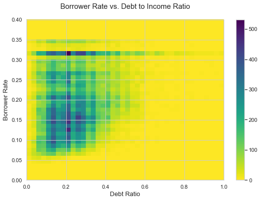

```python
# Histogram of interest rate and debt to income ratio.
# To be able to best depict the relationship between variables,
# debt ratio up to 1 is taken since the percentage of values greater
# than one is tiny.

plt.figure(figsize = (9,6))
# Setting bin values for 2d histogram
x_bins = np.arange(0, 1+0.025, 0.025)
y_bins = np.arange(0, 0.4+0.01, 0.01)
plt.hist2d(data = dff, y = 'BorrowerRate', x = 'DebtToIncomeRatio', bins = [x_bins, y_bins], cmap= 'viridis_r');
plt.colorbar();

# Setting title, ticks and labels
plt.xlabel('Debt Ratio', fontsize = 13)
plt.ylabel('Borrower Rate',fontsize = 13)
plt.xticks(fontsize = 11)
plt.yticks(fontsize = 11)
plt.title('Borrower Rate vs. Debt to Income Ratio\n', fontsize = 16);
```

From the histogram of interest rate and debt to income ratio above, it is seen that for debt to income ratio values between 5% and 25%, there are loans borrowed at any rate between 6% and 32%. But when debt ratio exceeds 35%, the lower end of borrower rate range increases in the histogram. It basically says, the smallest interest rate the borrowers pay increases as the debt ratio increases when the debt ratio is larger than 35%. The largest interest rate does not change with debt ratio and it is around 32%. The smallest interest rate borrowers with debt ratio exceeding 35% pay increases as debt ratio increases. So there seems to be a positive correlation between two. We can be sure by looking at the regression plot. It is given below and positive correlation is apparent in regression plot.

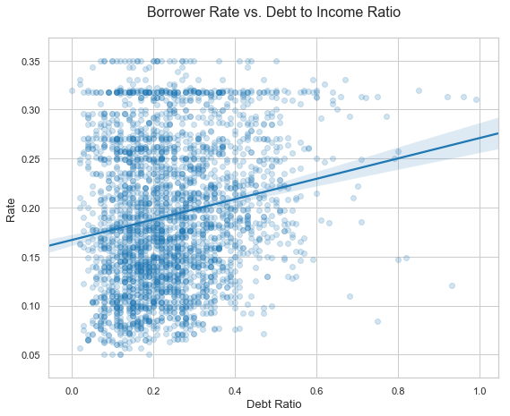

```python
# Regression plot of debt ratio and interest rate
# To be able to best depict the relationship between variables,
# debt ratio up to 1 is taken since the percentage of values greater
# than one is tiny.

sns.set_style('whitegrid')
plt.figure(figsize = (9, 7))
plot_data = dff[dff.DebtToIncomeRatio < 1].sample(3000)
sns.regplot(data = plot_data, x = 'DebtToIncomeRatio', y = 'BorrowerRate',
           scatter_kws = {'alpha': 0.2}, color = base_color);

# Setting title, labels and ticks
plt.xlabel('Debt Ratio',fontsize = 13)
plt.ylabel('Rate',fontsize = 13)
plt.xticks(fontsize = 11)
plt.yticks(fontsize = 11)
plt.title('Borrower Rate vs. Debt to Income Ratio\n', fontsize = 16);
```

### Borrower Rate and Current Credit Lines

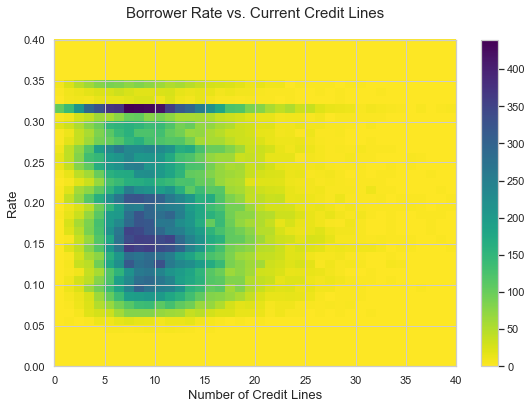

```python
# Histogram of interest rate and the number of credit lines of borrower
plt.figure(figsize = (9, 6))

# Setting bins for histogram
x_bins = np.arange(0, 40+1, 1)
y_bins = np.arange(0, 0.4+0.01, 0.01)
plt.hist2d(data = dff, y = 'BorrowerRate', x = 'CurrentCreditLines', bins = [x_bins, y_bins], cmap= 'viridis_r');
plt.colorbar();

# Setting title,  labels and ticks
plt.xlabel('Number of Credit Lines',fontsize = 13)
plt.ylabel('Rate',fontsize = 13)
plt.xticks(fontsize = 11)
plt.yticks(fontsize = 11)
plt.title('Borrower Rate vs. Current Credit Lines\n', fontsize = 16);
```

There is no obvious relationship between variables in the histogram, maybe a very small negative correlation. So I try pointplot to see the relationship clearly.

In the point plot below, as credit lines increases from 0 to up until 10, the average borrower rate decreases, from 11 to 26 the rate remains steady, after 26, there is no clear relationship between two.

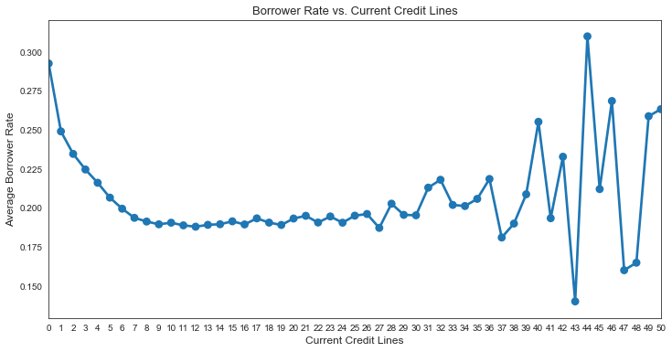

```python
# Pointplot of interest rate and the number of credit lines.
# Constrain the number of credit lines to 50, since there are
# a small number of outliers at very high values.

plt.figure(figsize = (12, 6))
sns.pointplot(data= dff, x = 'CurrentCreditLines', y = 'BorrowerRate', ci = None);
plt.xlim(0, 50);
ticks = np.arange(0, 51, 1)
plt.xticks(ticks, ticks);
plt.xlabel('Current Credit Lines', fontsize = 12);
plt.ylabel('Average Borrower Rate', fontsize = 12);
plt.title('Borrower Rate vs. Current Credit Lines', fontsize = 13);
```

### Correlation Matrix

The correlation matrix gives the Pearson correlation coefficients between numerical variables in the dataset. It is seen that borrower rate is positively correlated with the number of inquiries in last 6 months, debt to income ratio, the number of delinquencies in the last 7 years and negatively correlated to employment status duration, loan amount, current credit lines, monthly income and credit risk score.

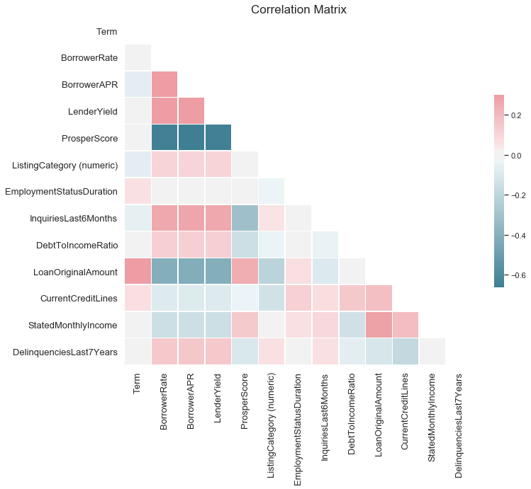

```python
# Heatmap of Correlation Matrix of Pearson coefficients
d = dff[cols]
corr = d.corr()  # Correlation Matrix
mask = np.zeros_like(corr, dtype = np.bool) # Mask to see only the lower part of the correlation matrix as it is symmetric
mask[np.triu_indices_from(mask)] = True     # there will be no loss of information and it makes reading easier.

cmap = sns.diverging_palette(220, 10, as_cmap = True)
plt.figure(figsize = (11, 10))
sns.heatmap(corr, mask = mask, cmap = cmap, vmax = 0.3, center = 0, square = True,
            linewidths = 0.5, cbar_kws = {'shrink':0.5});
plt.xticks(fontsize = 13);
plt.yticks(fontsize = 13);
plt.title('Correlation Matrix', fontsize = 17);
```

### Correlation with Borrower Rate

The price the borrower pays for the loan (borrower's rate) decreases as

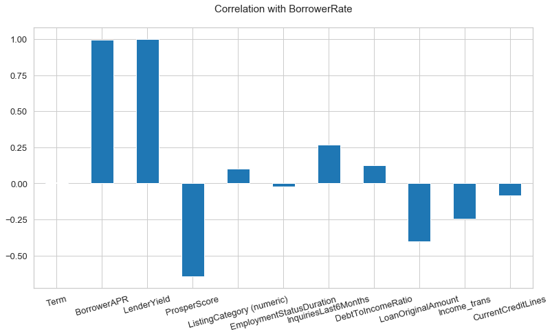

```python
# Correlation of other variables in the dataset with Borrower Rate

new_cols = ['Term', 'BorrowerAPR', 'LenderYield', 'ProsperScore', 'ListingCategory (numeric)', 'BorrowerState',
       'Occupation', 'EmploymentStatus', 'EmploymentStatusDuration', 'InquiriesLast6Months', 'DebtToIncomeRatio',
        'LoanOriginalAmount', 'Income_trans', 'CurrentCreditLines']

sns.set_style('whitegrid')
plt.figure(figsize =(13,7))
dff[new_cols].corrwith(dff['BorrowerRate']).plot(kind = 'bar',  color = base_color, grid = True);
plt.title('Correlation with BorrowerRate\n', fontsize= 15)
plt.xticks(rotation = 15, fontsize = 13);
plt.yticks(fontsize = 13);
```

## Are there differences between loans depending on how large the original loan amount was?

In this section, I will look at the relationship between loan amount and other variables.

### Loan Amount and Term

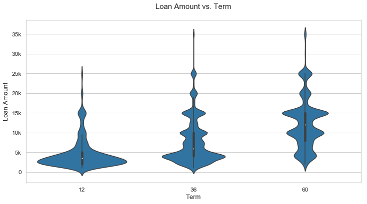

```python
# Violin plot of term and loan amount
plt.figure(figsize = (12, 6))
sns.violinplot(data = dff, x = 'Term', y = 'LoanOriginalAmount', color = base_color)

# Setting title, labels and ticks. Showing 5k instead of 5000 on the x-axis
plt.title('Loan Amount vs. Term\n', fontsize = 15);
ticks = np.arange(0, 35000 + 5000, 5000)
labels = ['0', '5k', '10k', '15k', '20k', '25k', '30k', '35k']
plt.yticks(ticks, labels, fontsize = 12);
plt.xticks(fontsize = 12)
plt.ylabel('Loan Amount', fontsize = 13);
plt.xlabel('Term', fontsize = 13);
```

From violinplots above, it can be seen that as term increases the average loan amount increases. Most of the 12-month loans are smaller than 5k. 60-month loans have spikes at 10k, 15k, 20k and 25k.

To be able to see the relationship more clearly, I do binning for loan amount; from 1 to 12 with 1 being the bin for smallest amount of loans and 12 being the bin for largest loan amounts. The pointplot below shows average term value for different bins. Even though term does not increase monotonically with loan amount especially for loan amounts greater than bin 5, we can say the average term is small for small loans and it is large for large loans. It is understandable since if borrower takes out $100k, he possibly does need a longer duration of time to pay it back. And it is also possible that for small loan amounts we might not have the options like 3 years or 5 years to pay it back.

```python
# Binning loan amount
bins = np.arange(999, 35000+3000, 3000)
labels = np.arange(1, 13)
dff['loan_amount']= pd.cut(dff['LoanOriginalAmount'], bins = bins, labels = labels )
```

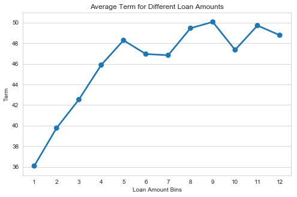

```python
# Point Plot of loan amountbin and term
plt.figure(figsize = (8,5))
sns.pointplot(data = dff, x = 'loan_amount', y = 'Term', ci = None);
plt.xlabel('Loan Amount Bins');
plt.title('Average Term for Different Loan Amounts', fontsize = 12);
```

### Loan Amount and Borrower Rate

Point plot gives idea about the mean interest rate of loan amount bins. We can get more details by looking at histogram of interest rate and loan amount. Histogram is given below.

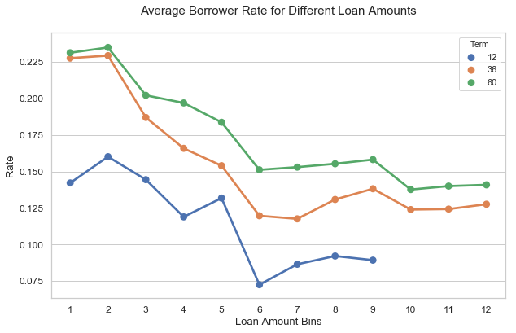

```python
# Point plot of loan amount and interest rate for different term values
plt.figure(figsize = (10, 6))
sns.pointplot(data = dff, x = 'loan_amount', y = 'BorrowerRate', hue = 'Term', ci = None);
plt.xlabel('Loan Amount Bins', fontsize = 13);
plt.title('Average Borrower Rate for Different Loan Amounts\n', fontsize = 15);
plt.ylabel('Rate', fontsize = 13);
plt.xticks(fontsize = 12)
plt.yticks(fontsize = 12);
```

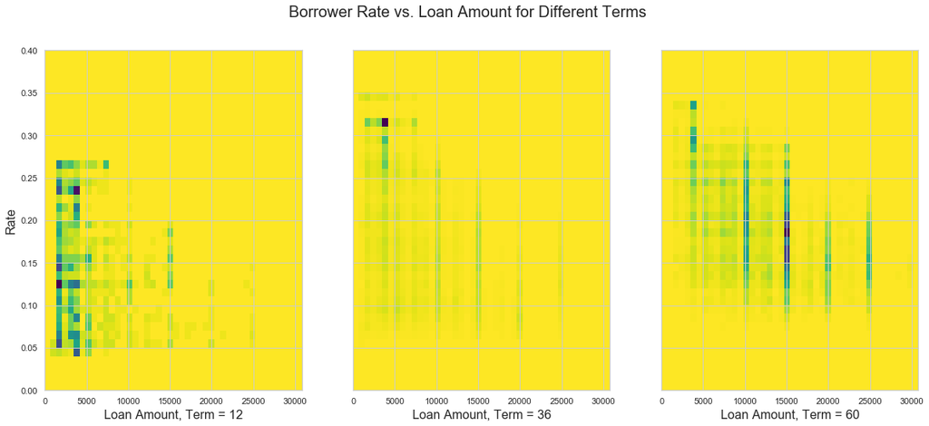

```python
# 3 histograms for 3 different term values
fig, ax= plt.subplots(1, 3, sharey = True, figsize = (20, 8));
# Setting bins for x-axis and y-axis
x_bins = np.arange(0,30000+1000, 700)
y_bins = np.arange(0, 0.4+0.01, 0.01)
# Adding subplots
ax[0].hist2d(data = dff[dff.Term == 12], x = 'LoanOriginalAmount', y = 'BorrowerRate',
             bins = [x_bins, y_bins], cmap = 'viridis_r');

ax[1].hist2d(data = dff[dff.Term == 36], x = 'LoanOriginalAmount', y = 'BorrowerRate',
             bins = [x_bins, y_bins], cmap = 'viridis_r');

ax[2].hist2d(data = dff[dff.Term == 60], x = 'LoanOriginalAmount', y = 'BorrowerRate',
             bins = [x_bins, y_bins], cmap = 'viridis_r');

# Setting ticks onx-axis
ticks = np.arange(0, 30000 + 5000, 5000);
labels = ['0', '5k', '10k', '15k', '20k', '25k', '30k'];

ax[0].set_ylabel('Rate', fontsize = 16);

for i in range(3):
    ax[i].set_xticks(ticks, labels);

ax[0].set_xlabel('Loan Amount, Term = 12', fontsize = 16);
ax[1].set_xlabel('Loan Amount, Term = 36', fontsize = 16);
ax[2].set_xlabel('Loan Amount, Term = 60', fontsize = 16);
plt.suptitle('Borrower Rate vs. Loan Amount for Different Terms', fontsize = 20);
```

When term increases, the borrower rate range for the same amount of loan shifts above. As loan amount increases for the same term, the upper end of borrower rate decreases. It means, for small loans, as term increases interest rate for the same loan amount increases for borrowers. But for the same term value, as loan amount increases, upper end of borrower rate range decreases. It means for the same term value, large loans are borrowed at a lower interest rate. In conclusion, as loan amoount increases, interest rate decreases.

It is also apparent that most of the loans with 12 month term are loans smaller than 5k whereas for 60 month loans most people borrow loans at multiple of 5k like 10k, 15k, 20k and 25k. And most of the large loans have a term of 60 months. We see very little number of loans greater than 15k with term of 12 months.

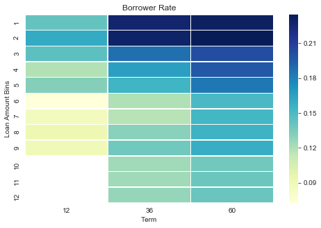

```python
# Heatmap of interest rate for different loan amount bins and term.
plt.figure(figsize = (8,5))
d = dff.sort_values(by ='loan_amount')
crosstab3 = pd.crosstab(d['loan_amount'], d['Term'], values = d['BorrowerRate'], aggfunc = 'mean')
sns.heatmap(crosstab3, cmap = 'YlGnBu', linewidth = .5, square = False);
plt.ylabel('Loan Amount Bins')
plt.title('Borrower Rate', fontsize = 12);
```

### Loan Amount and Income

The scatter plot shows income and loan amount for different term values. Even though there seems to be a positive correlation especially for 60-month loans (green), the plot is not very decisive and clean since there are many data points and data points with different colors overlap. So I use jointgrid to plot the histogram. It is given below.

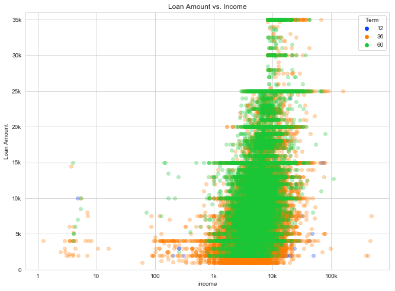

```python
# Scatter plot of loan amount and log-transformed income for different
# term values.
# First select all samples with terms being equal to 12, 36 or 60 and plot
# the data with log-transformed income.

plt.figure(figsize = (11,8))
colors = sns.color_palette('bright', 3)
for i, color in zip([12, 36, 60], colors):
    plot_data = dff[dff.Term == i]
    sns.scatterplot(data = plot_data, y = 'LoanOriginalAmount', x = 'Income_trans', color = color,
                   alpha = 0.3, edgecolor = None)

# Creating legend object to say which color is which term value
legend_obj = []
for color in colors:
    legend_obj.append(plt.scatter([], [], color = color))
plt.legend(legend_obj, ['12', '36', '60'], title = 'Term');

plt.xlabel('income')
plt.ylabel('Loan Amount')
plt.title('Loan Amount vs. Income')

# Polishing the graph. Showing income and loan amount as 10k instead of 10000
ticks = np.arange(0, 35000 + 5000, 5000)
labels = ['0', '5k', '10k', '15k', '20k', '25k', '30k', '35k']
plt.yticks(ticks, labels, fontsize = 10);
plt.ylim(0, 36000)
ticks = np.arange(0, 5+1, 1)
labels = ['1', '10', '100', '1k', '10k', '100k']
plt.xticks(ticks, labels);
```

```python
import matplotlib
```

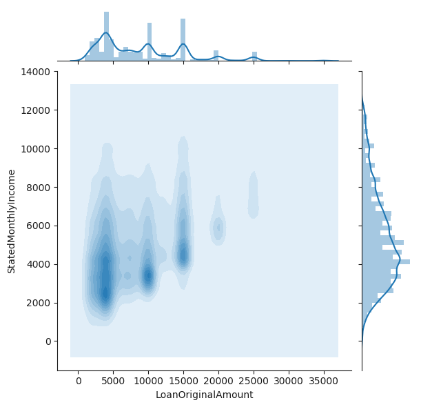

```python
# Joint Plot of loan amount and income
# cutting the outliers in income,taking only values with income at most 13k

inline_rc = dict(matplotlib.rcParams)
matplotlib.rcParams.update(matplotlib.rcParamsDefault)
g = sns.JointGrid(data = dff[dff.StatedMonthlyIncome < 12500], x = 'LoanOriginalAmount', y = 'StatedMonthlyIncome')
g = g.plot_joint(sns.kdeplot, shade = True)
g = g.plot_marginals(sns.distplot)
```

In the joint plot, as the loan amount increases, the lower end of income range shifts upward and range gets smaller. It basically says that, small loans are borrowed by people with a wide range of income whereas large loans are taken out only by people with high income. So as income of borrowes gets larger as increasing loan amount.

Histogram of variables is given below, it supports what we are saying. The minimum income of borrowers increases as the loan amount increases. In other words, large loans are borrowed by people with high income, not borrowed by (or maybe given to) people with low income.

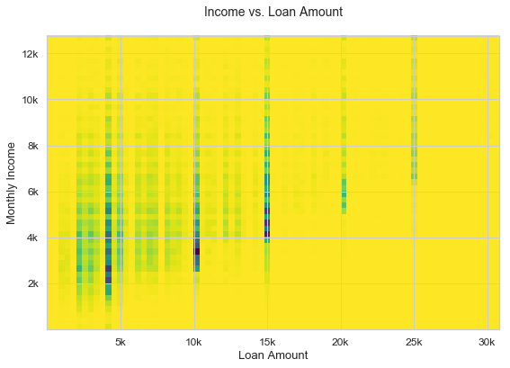

```python
# Histogram of loan amount and income
# setting bins on the x-axis and y-axis
plt.figure(figsize = (9,6))
x_bins = np.arange(0, 30000 + 1000, 400)
y_bins = np.arange(0, 12500 + 500, 250)

plt.hist2d(data = dff, x = 'LoanOriginalAmount', y = 'StatedMonthlyIncome', bins = [x_bins, y_bins],
          cmap = 'viridis_r');

# Polishing the graph. Showing 10k instead of 10000 on the axes.
ticks = np.arange(5000, 30000 + 5000, 5000)
labels = ['5k', '10k', '15k', '20k', '25k', '30k']
plt.xticks(ticks, labels, fontsize = 12);

ticks_y = np.arange(2000, 12000 + 2000, 2000)
labels_y = ['2k', '4k', '6k', '8k', '10k', '12k']
plt.yticks(ticks_y, labels_y, fontsize = 12);

# Setting title and labels
plt.xlabel('Loan Amount', fontsize = 13)
plt.ylabel('Monthly Income', fontsize = 13)
plt.title('Income vs. Loan Amount\n', fontsize = 14);
```

Point plot shows the average stated monthly income for different loan amount bins. The positive correlation between loan amount and monthly income is apparent in the graph. The mean income of borrowers increases as the loan amount increases. For instance the average income of people who take out loans between 32k and 35k is around 14k whereas this number is around 4500 for people who borrow between 1k and 4k.

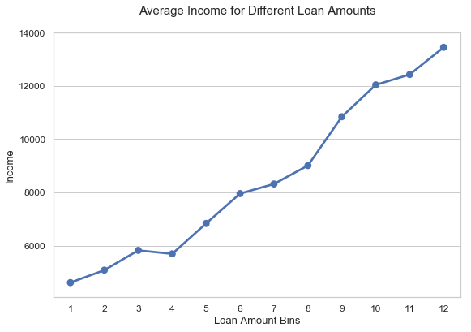

```python
# Point plot showing average monthly income for different loan amount bins.
plt.figure(figsize = (9,6))
sns.pointplot(data = dff, x = 'loan_amount', y = 'StatedMonthlyIncome', ci = None);
plt.xlabel('Loan Amount Bins', fontsize = 13)
plt.ylabel('Income', fontsize = 13)
plt.title('Average Income for Different Loan Amounts\n', fontsize = 15);
plt.xticks(fontsize = 12);
plt.yticks(fontsize = 12);
```

### Loan Amount and Credit Score

As the loan amount increases, the lower end of credit risk score range shifts upward. It means that as loans get larger, the credit score of borrowers who get these loans get larger. So there is a positive correlation between loan amount and credit risk score.

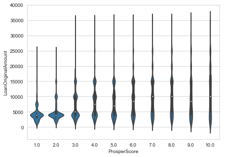

```python
# Violin plot showing the distribution of loan amount for different credit risk score
plt.figure(figsize = (7, 5))
sns.violinplot(data = dff, x = 'ProsperScore', y = 'LoanOriginalAmount', color = base_color);
```

Violin plot shos the distribution of loan amount for different credit risk scores. For small credit scores, the distribution is more compact and most of the loans are smaller than 5k. As credit score increases, the distribution gets more spread and the mean value generally gets larger . There are lumps at values 10k, 15k, 20k and 25k. This plot gives insight but is not sufficinet to tell how large loans are different from smaller loans in terms of credit score. Next I try to use heatmap.

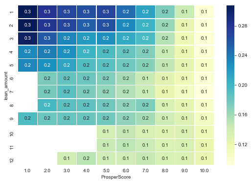

```python
# Heatmap showing average interest rate for different credit risk score and loan amount bins.

plt.clf()
plt.figure(figsize = (9, 6))
d = dff.sort_values(by ='loan_amount')
crosstab4 = pd.crosstab(d['loan_amount'], d['ProsperScore'], values = d['BorrowerRate'], aggfunc = 'mean')
sns.heatmap(crosstab4, annot = True, fmt = '.1f', cmap = 'YlGnBu', linewidth = .5, square = False);
```

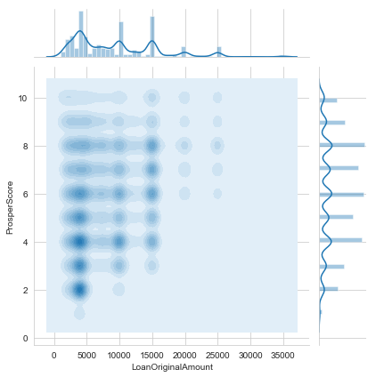

```python
# The histogram of loan amount and credit risk score on the edges
# The bivariate kernel density estimation plot at the joint

g = sns.JointGrid(data = dff, x = 'LoanOriginalAmount', y = 'ProsperScore')
g = g.plot_joint(sns.kdeplot, shade = True)
g = g.plot_marginals(sns.distplot)
```

As the loan amount increases, the lower end of credit risk score range shifts upward. It means that as loans get larger, the credit score of borrowers who get these loans get larger. In other words, large loans are not borrowed by people who have low credit score. So there is a positive correlation between loan amount and credit risk score.

It is also evident in the histogram below.

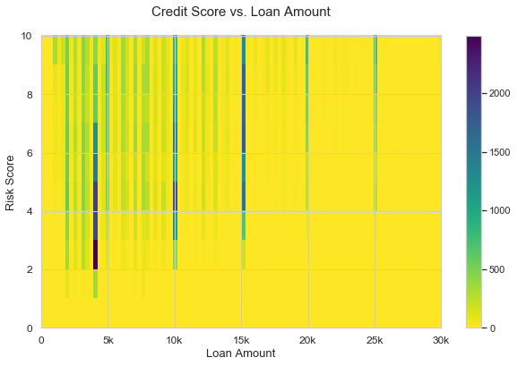

```python
# 2d Histogram of risk score and loan amount
# Setting bins for x and y-axis
plt.figure(figsize = (10,6))
x_bins = np.arange(0, 30000+ 300, 300)
y_bins = np.arange(0, 11)
plt.hist2d(data = dff, y = 'ProsperScore', x = 'LoanOriginalAmount', cmap = 'viridis_r',
          bins = [x_bins, y_bins]);
plt.colorbar()

# Setting ticks on x-axis and y-axis. Showing 10k instead of 10000
ticks = np.arange(0, 30000 + 5000, 5000)
labels = ['0', '5k', '10k', '15k', '20k', '25k', '30k']
plt.xticks(ticks, labels, fontsize = 12);
plt.yticks(fontsize = 12);

# Setting title and labels
plt.xlabel('Loan Amount', fontsize = 13)
plt.ylabel('Risk Score', fontsize = 13)
plt.title('Credit Score vs. Loan Amount\n', fontsize = 15);
```

At this point, it would be nice to look at credit score distribution of people who get small and large loans and compare these. I define large loans as loans that are at least 15k and small loans as loans at most 10k. The distributions are given below. Large loans (loans greater than 15k) are given to people whose credit score is high. The credit score distribution is left-skewed. It basically means that large loans are not given to (or not borrowed by) people with low credit scores. That is probably the reason why we see a negative correlation between loan amount and interest rate. On the other hand, we see that the credit score distribution of people who borrow small loans is symmetric and kind of uniform. Person with any credit score borrows small loans.

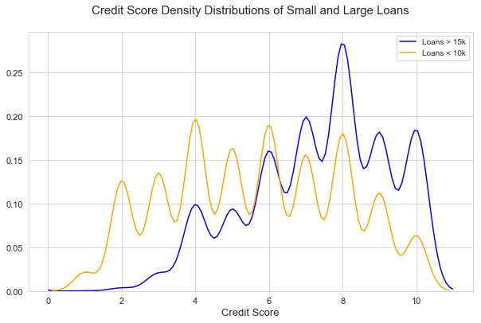

```python
# Density distributions of credit score of people who borrow small and large loans.
plt.figure(figsize = (10, 6))
plot_data = dff[dff.LoanOriginalAmount > 15000]  # large loans that are larger than 15k
sns.kdeplot(plot_data['ProsperScore'], color = 'blue', shade = False);
plot_data2 = dff[dff.LoanOriginalAmount < 10000] # small loans that are smaller than 10k
sns.kdeplot(plot_data2['ProsperScore'], color = 'orange', shade = False);

# Adding title and labels
plt.xlabel('Credit Score', fontsize = 13)
plt.xticks(fontsize = 11)
plt.yticks(fontsize = 11)
plt.title('Credit Score Density Distributions of Small and Large Loans\n', fontsize = 15);

# changing the text in the legend
L = plt.legend()
L.get_texts()[0].set_text('Loans > 15k')
L.get_texts()[1].set_text('Loans < 10k');
```

### Loan Amount and Debt to Income Ratio

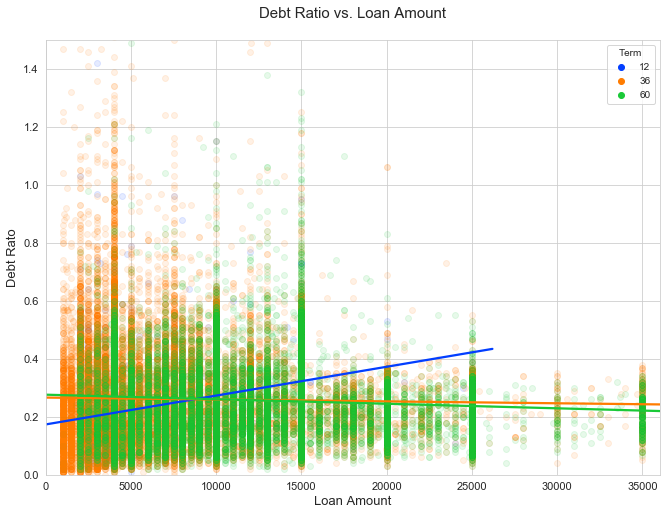

```python
# Regression plot of loan amount and debt to income ratio for term values of 12, 36 and 60
# select the plot_data first whose term is equal to 12, 36 or 60 and then
# plot it with different color.

plt.figure(figsize = (11, 8))
colors = sns.color_palette('bright', 3)
for i, color in zip([12, 36, 60], colors):
    plot_data = dff[dff.Term == i]
    sns.regplot(data = plot_data, x = 'LoanOriginalAmount', y = 'DebtToIncomeRatio', color = color, ci = None,
               scatter_kws = {'alpha':0.1})
plt.ylim(0, 1.5)
plt.xlim(0,36000)

# Creating legend object
legend_obj = []
for color in colors:
    legend_obj.append(plt.scatter([], [], color = color))
plt.legend(legend_obj, ['12', '36', '60'], title = 'Term');

# Adding title, labels
plt.xlabel('Loan Amount', fontsize = 13)
plt.ylabel('Debt Rato', fontsize = 13)
plt.xticks(fontsize = 11)
plt.yticks(fontsize = 11)
plt.title('Debt Ratio vs. Loan Amount\n', fontsize = 15);
```

From regression plot above, we see that there is a positive correlation between loan amount and debt ratio for 12-month loans. For 3 and 5-year loans, the slope of the regression plot is small and negative. From joint plot below, for very large loan amounts debt ratio is around 20%. For small amounts, debt ratio is between 0 and 60%. So the plots are indecisive about the relationship between loan amount and debt ratio.

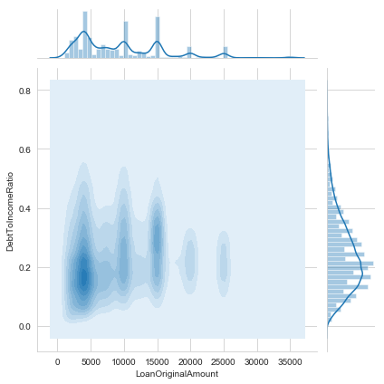

```python
# PLotting kdeplot of loan amount and debt to income ratio
plot_data = dff[dff.DebtToIncomeRatio < 0.8]
g = sns.JointGrid(data = plot_data, x = 'LoanOriginalAmount', y = 'DebtToIncomeRatio')
g = g.plot_joint(sns.kdeplot, shade = True)
g = g.plot_marginals(sns.distplot)
```

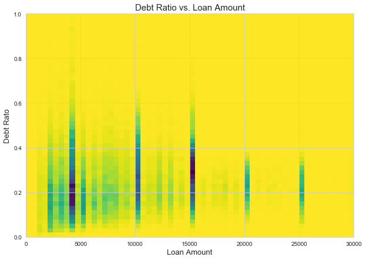

```python
# Histogram of debt ratio and loan amount
plt.figure(figsize = (10, 7))
# Setting bins for x and y axis
x_bins = np.arange(0, 30000+ 500, 500)
y_bins = np.arange(0, 1+0.02, 0.02)
plt.hist2d(data = dff, y = 'DebtToIncomeRatio', x = 'LoanOriginalAmount', cmap = 'viridis_r',
          bins = [x_bins, y_bins]);
# Adding title and labels
plt.xlabel('Loan Amount', fontsize = 13)
plt.ylabel('Debt Rato', fontsize = 13)
plt.title('Debt Ratio vs. Loan Amount', fontsize = 15);
```

### Correlation with Loan Amount

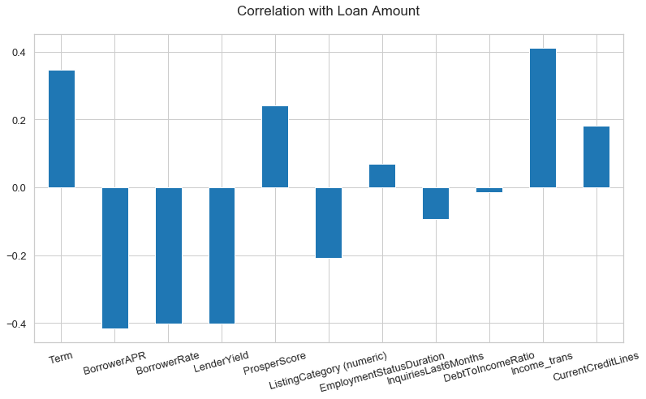

```python
sns.set_style('whitegrid')
new_cols = ['Term', 'BorrowerAPR', 'BorrowerRate', 'LenderYield', 'ProsperScore', 'ListingCategory (numeric)', 'BorrowerState',
       'Occupation', 'EmploymentStatus', 'EmploymentStatusDuration', 'InquiriesLast6Months', 'DebtToIncomeRatio',
        'Income_trans', 'CurrentCreditLines']  # the columns I want to see in the plot
sns.set_style('whitegrid')
plt.figure(figsize =(13,7))
dff[new_cols].corrwith(dff['LoanOriginalAmount']).plot(kind = 'bar',  color = base_color, grid = True);
plt.xticks(rotation = 15, fontsize = 13);
plt.yticks(fontsize = 13);
plt.title('Correlation with Loan Amount\n', fontsize = 17);
```

```python
#dff.to_csv('clean_data.csv', index = False)
```